# Losses Estimates from the Extreme Weather Condition in US

Cy

10/7/2020

## Synopsis

This project involves exploring the U.S. National Oceanic and Atmospheric Administration’s (NOAA) storm database. This database tracks characteristics of major storms and weather events in the United States, including the estimates of any fatalities, injuries, and property damage.  
This analysis is divided into two parts.  
Part 1 analyzes the fatalities and injuries caused by extreme weather conditions. Top 10 of event types are extracted and presented in graph.  
Meanwhile, part 2 speaks about the Top 10 economic consequences in terms of property and agricultural crops damage.

```r
library(dplyr)
```

```r
library(ggplot2)
library(tidyr)
```

## Data Processing

Download the data from website and read into “raw”

```r
if(!file.exists("storm.csv.bz2"))
        {
download.file("https://d396qusza40orc.cloudfront.net/repdata%2Fdata%2FStormData.csv.bz2",
                destfile = "storm.csv.bz2")
        }

raw<-read.csv(bzfile("storm.csv.bz2"))
```

Subsetting useful columns

```r
raweco<-raw[ ,c(8,23:28)]
```

Replacing all typos and similar event type into one category. ie: Whirlwind & WHIRLWIND depending on 2.1.1 event table

```r
j<-list("WHIRLWIND","WATERSPOUT","VOLCANIC","FLOOD","THUNDERSTORM","SNOW")

for (i in 1:length(j)){
                raweco$EVTYPE[grepl(j[[i]],raweco$EVTYPE,ignore.case = TRUE)]<-j[[i]]
                }

raweco$EVTYPE<-factor(raweco$EVTYPE)
```

COnverting the prefix into value and create a new columns to store these values

```r
raweco$PROPDMGEXP<-recode(raweco$PROPDMGEXP,"K"=1000,"M"=1000000,"B"=1000000000,.default = 1)
raweco$CROPDMGEXP<-recode(raweco$CROPDMGEXP,"K"=1000,"M"=1000000,"B"=1000000000,.default = 1)
raweco$prop<-raweco$PROPDMG*raweco$PROPDMGEXP
raweco$crop<-raweco$CROPDMG*raweco$CROPDMGEX
```

## Results

### Top 10 most harmful events.

The data is grouped by event type and pivoted according to fatalities and injuries. Top 10 events with injuries and fatalities are shown

```r
harm<-raweco%>%group_by(EVTYPE)%>%summarise('FATALITIES'=sum(FATALITIES),'INJURIES'=sum(INJURIES))%>% arrange(desc(FATALITIES+INJURIES))
print(harm[1:10,])
```

```
## # A tibble: 10 x 3
##    EVTYPE         FATALITIES INJURIES
##    <fct>               <dbl>    <dbl>
##  1 TORNADO              5633    91346
##  2 FLOOD                1525     8604
##  3 EXCESSIVE HEAT       1903     6525
##  4 TSTM WIND             504     6957
##  5 LIGHTNING             816     5230
##  6 HEAT                  937     2100
##  7 THUNDERSTORM          210     2479
##  8 ICE STORM              89     1975
##  9 WINTER STORM          206     1321
## 10 HIGH WIND             248     1137
```

Extract top 10 and create plot

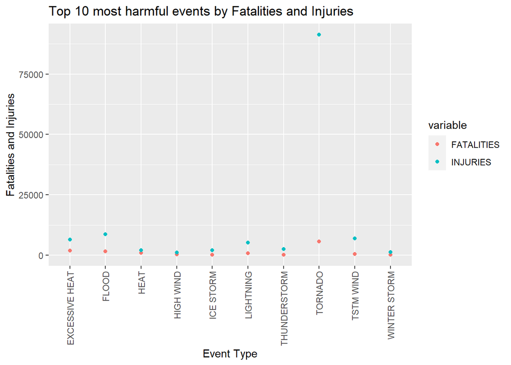

```r
harm$EVTYPE<-factor(harm$EVTYPE)
harm10<-harm[1:10,]
df<-harm10%>%select(EVTYPE,FATALITIES,INJURIES)%>%gather(key = "variable",value="value",FATALITIES:INJURIES)
p1<-ggplot(df, aes(x = EVTYPE, y = value))+geom_point(aes(color = variable))+theme(axis.text.x = element_text(angle = 90, vjust = 0.5, hjust=1))+labs(y="Fatalities and Injuries",x="Event Type",title = "Top 10 most harmful events by Fatalities and Injuries")

print(p1)
```

### Top 10 most economical harmful events

```r
econ<-raweco%>% group_by(EVTYPE)%>% summarise('prop'=sum(prop),'crop'=sum(crop))%>% arrange(desc(prop+crop))
print(econ[1:10,])
```

```
## # A tibble: 10 x 3
##    EVTYPE                     prop        crop
##    <fct>                     <dbl>       <dbl>
##  1 FLOOD             167529740932. 12380099110
##  2 HURRICANE/TYPHOON  69305840000   2607872800
##  3 TORNADO            56925660790.   414953270
##  4 STORM SURGE        43323536000         5000
##  5 HAIL               15727367053.  3025537890
##  6 DROUGHT             1046106000  13972566000
##  7 HURRICANE          11868319010   2741910000
##  8 ICE STORM           3944927860   5022113500
##  9 TROPICAL STORM      7703890550    678346000
## 10 THUNDERSTORM        6429566986.   652971392
```

Extract top 10 and create plot

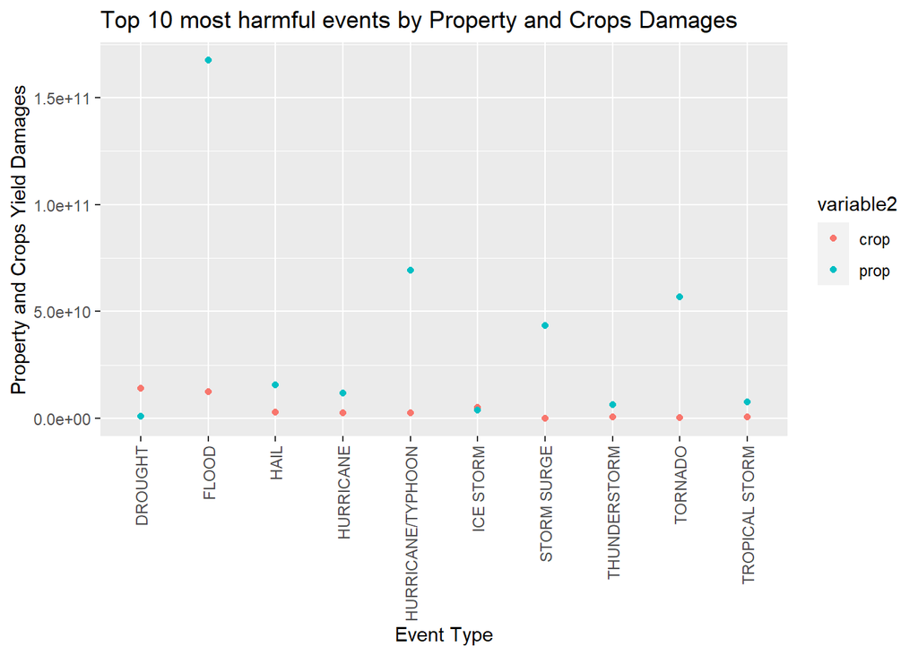

```r
econ$EVTYPE<-factor(econ$EVTYPE)
econ10<-econ[1:10,]
df2<-econ10%>%select(EVTYPE,prop,crop)%>%gather(key="variable2",value = "value2",crop:prop)
p2<-ggplot(df2,aes(x=EVTYPE,y=value2))+geom_point(aes(color=variable2))+theme(axis.text.x = element_text(angle = 90, vjust = 0.5, hjust=1))+labs(y="Property and Crops Yield Damages",x="Event Type",title ="Top 10 most harmful events by Property and Crops Damages")

print(p2)
```

*The most disastrous event is Flood, followed by Hurricane/Typhoon, Tornado and Storm Surge*